# Figure 4

Percentage of CD14 positive (box plot)

Claire, Marceaux, Ilariya Tarasova

February 27, 2025

# 1 Preparation

In this file we calculate the percentage of CD14 positive T cells relative to the total CD14+ and CD14- cell subtype (two cohorts: CM and Sorin).

## 1.1 Read the data

```r
> #cells_Enfield <- readRDS(file="../../data/Enfield_tumor_cells_info.rds")
> #patient_survival_Enfield <- readRDS(file="../../data/Enfield_patient_survival.rds")
> cell_info_sorin <- readRDS(file="../../data/Sorin_cell_info.rds")
> patient_counts_CM <- readRDS(file="../../data/CM_patient_counts_no_compartment_all_FM_TRM_df.rds")
```

## 1.2 Source the functions

```r
> source('../../src/calculate_cell_type_percentages.R')
```

## 1.3 Set the output folder

```r
> output_folder <- "../plots/"
> if (!dir.exists(output_folder)){
+     dir.create(output_folder, recursive = T)
+ }
```

## 1.4 Set the colors

```r
> cd14pos_colors <- c(
+     "mediumorchid3",
+     "mediumpurple3",
+     #"salmon3" - that was for NK CD14+, for usual NK is salmon1
+     "pink3"
+ )
```

# 2 Function

```r
> do_boxplot_cd14pos_percentage <- function(percentages_df, cd14pos_colors, dodge){
+   p <- ggplot(percentages_df, aes(x = percentage, y=value)) +
+     # The actual box plot
+     geom_boxplot(aes(fill=percentage), position = position_dodge(dodge))+
+     # The jitter plot
+     geom_jitter(aes(fill=percentage), alpha=1, size=2, position = position_dodge(dodge)) +
+     #scale_shape_manual(values = c( 19, 10 ,1 ))+
+     scale_fill_manual(values=cd14pos_colors) +
+     #scale_color_manual(values=c("black", "grey67", "grey")) +
+     #scale_alpha_manual(values=c(1, 0.7, 0.3)) +
+     theme(
+         axis.title.y=element_blank(),
+         axis.text.x = element_blank(),
+         axis.title.x = element_blank(),
+         panel.background = element_blank(),
+         axis.line.y = element_line(),
+         axis.line.x = element_line(),
+     )
+   return(p)
+ }
>
> do_ordered_boxplot <- function(percentages_df, cd14pos_colors_h3, dodge){
+   #Here we need to reorder by median value
+
+ ggplot(percentages_df, aes(x = reorder(percentage, value, FUN = median, decreasing=T),
+                            y=value)) +
+     # The actual box plot
+     geom_boxplot(aes(fill=percentage), position = position_dodge(dodge), width = 0.5)+
+     # The jitter plot
+     geom_jitter(aes(fill=percentage), alpha=1, size=2, position = position_dodge(dodge)) +
+     #scale_shape_manual(values = c( 19, 10 ,1 ))+
+     scale_fill_manual(values=cd14pos_colors_h3)+
+   theme(
+         axis.title.y=element_blank(),
+         axis.text.x = element_blank(), #element_text(angle=45, vjust = 1, hjust = 1),
+         axis.title.x = element_blank(),
+         panel.background = element_blank(),
+         axis.line.y = element_line(),
+         axis.line.x = element_line(),
+         legend.position="none"
+     )
+ }
```

# 3 CM

## 3.1 Calculate the percentage

```r
> group_cols <- c("Patient", "Cancer Type")
>
> cell_types <- c("CD8 T cells: CD14+",
+                 "CD4 T cells: CD14+",
+                 "Treg cells: CD14+")
>
> parent_type <- c("CD8 T cells",
+                  "CD4 T cells",
+                  "Treg cells")
>
> filter_type <- c("CD8 T cells",
+                  "CD4 T cells",
+                  "Treg cells")
>
> # calculate the proportions
> percentages_df <- calculate_cell_type_percentages(patient_counts_CM, group_cols,
+                                                   cell_types, parent_type,
+                                                   filter_types = filter_type)
```

```r
> # we need to filter out the proportions with less than 5 cells
> percentages_df <- percentages_df %>%
+     filter(filter_type_count >= 5)
>
> percentages_df <- percentages_df %>%
+     filter(parent_type_count>0)
```

## 3.2 Plot CD8, CD4, Treg (Fig 4C(i))

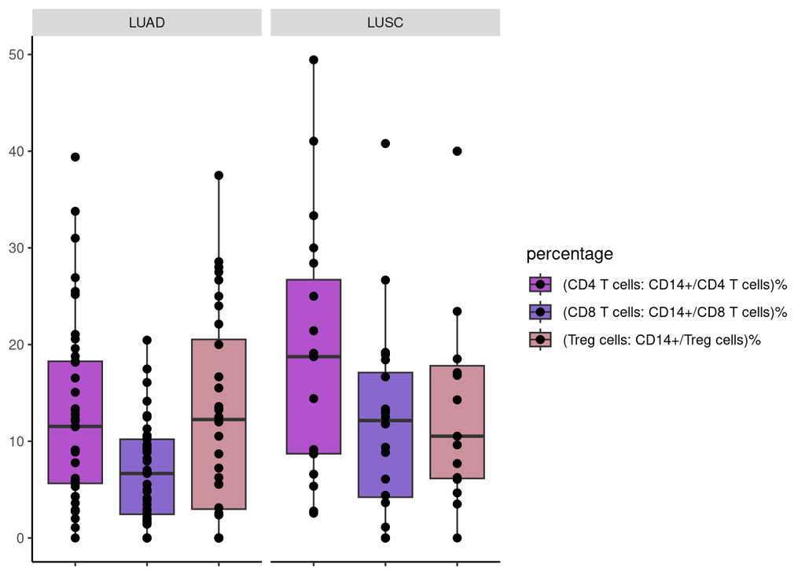

```r
> dodge <- 1
> run_name <- "CM_LUAD&LUSC_CD14subsets_no_compartments_Treg_instead_NK"
>
> do_boxplot_cd14pos_percentage(percentages_df, cd14pos_colors, dodge)+
+     facet_wrap(~ `Cancer Type`, nrow = 1, scales = "free_x")
```

```r
> ggsave(file.path(output_folder, paste0(run_name, "_no_pvalue_boxplots.png")))
```

## 3.3 Major cell types

```r
> patient_counts_CM <- patient_counts_CM %>% filter(`Cancer Type`=="LUAD")
>
> celltypes <- c(
+     "Dendritic cells: CD14+",
+     "Macrophages: CD14+",
+     "T cells: CD14+",
+     "B cells: CD14+",
+     "Granulocytes: CD14+",
+     "Mast cells: CD14+",
+     "NK cells: CD14+")
>
> denominators <- c(
+     "Dendritic cells",
+     "Macrophages",
+     "T cells",
+     "B cells",
+     "Granulocytes",
+     "Mast cells",
+     "NK cells")
>
> colors <- c(
+     "royalblue1",
+     "turquoise1",
+     "magenta1",
+     "red",
+     "seagreen1",
+     "greenyellow",
+     "salmon1")
>
> group_cols <- c("Patient")
> cell_types <- celltypes
> parent_type <- denominators
> filter_type <- parent_type
>
> # calculate the proportions
> percentages_df_test <- calculate_cell_type_percentages(patient_counts_CM, group_cols,
+                                                   cell_types, parent_type,
+                                                   filter_types = filter_type)
```

filter out the proportions with less than 5 cells

```r
> # we need to filter out the proportions with less than 5 cells
> percentages_df_test <- percentages_df_test %>%
+     filter(filter_type_count >= 5)
>
> percentages_df_test <- percentages_df_test %>%
+     filter(parent_type_count>0)
```

Plot

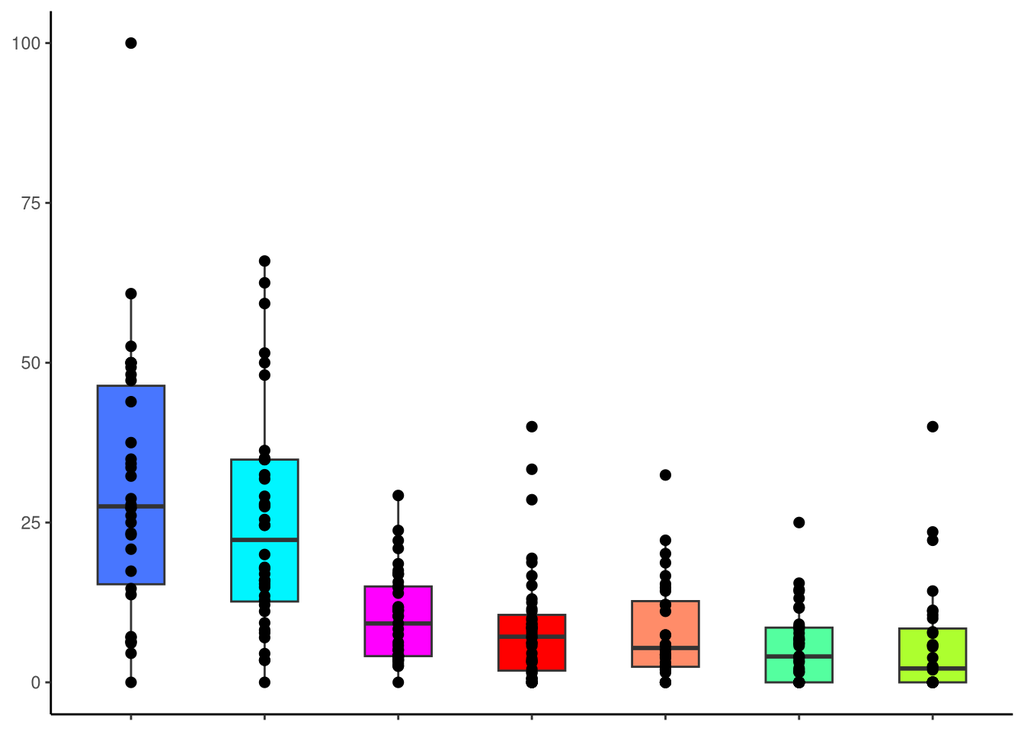

```r
> dodge <- 1
> run_name <- "LUAD_CD14Allsubsets_boxplots_no_compartments"
>
> percentages_df_test$percentage <- factor(percentages_df_test$percentage,
+                                     levels = unique(percentages_df_test$percentage))
>
> do_ordered_boxplot(percentages_df_test, colors, dodge)
```

```r
> ggsave(file.path(output_folder, paste0(run_name, "_boxplots.png")))
```

# 4 Sorin

## 4.1 T cell subset

### 4.1.1 Prepare the data

First, update cell type annotation to reflect CD14 status

```r
> table(cell_info_sorin$CellType)
```

```
         Alt MAC           B cell           Cancer           Cl MAC
           39502            62938           733774           155875
           Cl Mo         DCs cell Endothelial cell           Int Mo
           37653             1407           108387             8330
       Mast cell      Neutrophils          NK cell        Non-Cl Mo
            9480            42424             3701            17029
           Other          T other               Tc               Th
          129597            23995            98395           147979
            Treg
           19839
```

```r
> cell_info_sorin$updCellType <- as.character(cell_info_sorin$CellType)
> cell_info_sorin$updCellType <- ifelse(cell_info_sorin$updCellType == "Th" &
+                                         cell_info_sorin$CD14status == "pos",
+                                       "ThCD14+", cell_info_sorin$updCellType)
>
> cell_info_sorin$updCellType <- ifelse(cell_info_sorin$updCellType == "Tc" &
+                                         cell_info_sorin$CD14status == "pos",
+                                       "TcCD14+", cell_info_sorin$updCellType)
>
> cell_info_sorin$updCellType <- ifelse(cell_info_sorin$updCellType == "NK cell" &
+                                         cell_info_sorin$CD14status == "pos",
+                                       "NK_CD14+", cell_info_sorin$updCellType)
>
> cell_info_sorin$updCellType <- ifelse(cell_info_sorin$updCellType == "Treg" &
+                                         cell_info_sorin$CD14status == "pos",
+                                       "Treg_CD14+", cell_info_sorin$updCellType)
```

Calculate the cell numbers per patient

```r
> cell_info_sorin <- as.data.frame(cell_info_sorin)
> # First, count the occurrences of each cellType for each Patient
> patient_counts_Sorin <- cell_info_sorin %>%
+   group_by(Patient, CellType) %>%
+   summarize(count = n(), .groups = 'drop')
>
> # Reshape the data frame to have each cellType as a column
> patient_counts_Sorin <- patient_counts_Sorin %>%
+   spread(key = CellType, value = count, fill = 0)
>
> # Next, count the occurrences of each updCellType for each Patient
> patient_counts_with_cd14_Sorin <- cell_info_sorin %>%
+   group_by(Patient, updCellType) %>%
+   summarize(count = n(), .groups = 'drop')
>
> # Reshape the data frame to have each cellType as a column
> patient_counts_with_cd14_Sorin <- patient_counts_with_cd14_Sorin %>%
+   spread(key = updCellType, value = count, fill = 0)
>
> # Merge
> df_counts_Sorin <- patient_counts_with_cd14_Sorin %>%
+   select(., contains("Patient") | ends_with("CD14+")) %>%
+   left_join(patient_counts_Sorin, ., by = "Patient")
```

### 4.1.2 Calcilate percentage

```r
> group_cols <- c("Patient")
>
> cell_types <- c("TcCD14+",
+                 "ThCD14+",
+                 "Treg_CD14+")
>
> parent_type <- c("Tc",
+                  "Th",
+                  "Treg")
>
> filter_type <- parent_type
>
> # calculate the proportions
> percentages_df <- calculate_cell_type_percentages(df_counts_Sorin, group_cols,
+                                                   cell_types, parent_type,
+                                                   filter_types = filter_type)
```

```r
> # we need to filter out the proportions with less than 5 cells
> percentages_df <- percentages_df %>%
+     filter(filter_type_count >= 5)
>
> percentages_df <- percentages_df %>%
+     filter(parent_type_count>0)
```

### 4.1.3 Plot Th, Tc, Treg (Fig4C(ii))

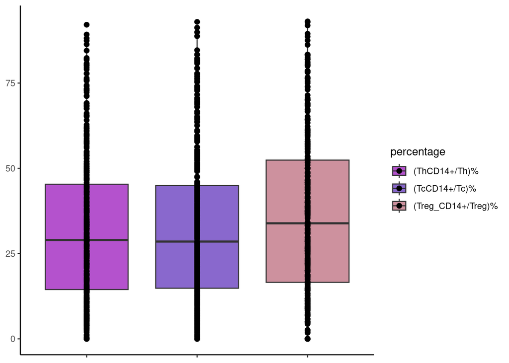

```r
> dodge <- 1
> run_name <- "Sorin_CD14subsets_Tcells_only"
>
> percentages_df$percentage <- factor(percentages_df$percentage,
+                                     levels = c("(ThCD14+/Th)%", "(TcCD14+/Tc)%", "(Treg_CD14+/Treg)%"))
>
> do_boxplot_cd14pos_percentage(percentages_df, cd14pos_colors, dodge)
```

```r
> ggsave(file.path(output_folder, paste0(run_name, "_no_pvalue_boxplots.png")))
```

## 4.2 Major cell types (Fig4A)

> Figure 4 : I will need for Sorin the % of CD14+ cells in T cells (combine the T cells together as you did for Fig3), B cells, macro (combine the macro together as you did for Fig3), neutron, mast cells, DC, mono (combine the mono together as you did for Fig3), using the colours I have used for my cohort

### 4.2.1 Prepare the data

Senity check

```r
> table(cell_info_sorin$CellType_h3[cell_info_sorin$CellType_h3 == "T cell"],
+       cell_info_sorin$CellType[cell_info_sorin$CellType_h3 == "T cell"])
```

```
         Alt MAC B cell Cancer Cl MAC  Cl Mo DCs cell Endothelial cell Int Mo
  T cell       0      0      0      0      0        0                0      0

         Mast cell Neutrophils NK cell Non-Cl Mo  Other T other     Tc     Th
  T cell         0           0       0         0      0   23995  98395 147979

           Treg
  T cell  19839
```

```r
> table(cell_info_sorin$CellType_h3[cell_info_sorin$CellType_h3 == "Macrophages"],
+       cell_info_sorin$CellType[cell_info_sorin$CellType_h3 == "Macrophages"])
```

```
              Alt MAC B cell Cancer Cl MAC  Cl Mo DCs cell Endothelial cell
  Macrophages   39502      0      0 155875      0        0                0

              Int Mo Mast cell Neutrophils NK cell Non-Cl Mo  Other T other
  Macrophages      0         0           0       0         0      0       0

                  Tc     Th   Treg
  Macrophages      0      0      0
```

```r
> table(cell_info_sorin$CellType_h3[cell_info_sorin$CellType_h3 == "Monocytes"],
+       cell_info_sorin$CellType[cell_info_sorin$CellType_h3 == "Monocytes"])
```

```
            Alt MAC B cell Cancer Cl MAC Cl Mo DCs cell Endothelial cell Int Mo
  Monocytes       0      0      0      0 37653        0                0   8330

            Mast cell Neutrophils NK cell Non-Cl Mo Other T other    Tc    Th
  Monocytes         0           0       0     17029     0       0     0     0

             Treg
  Monocytes     0
```

```r
> # First, count the occurrences of each cellType for each Patient
> patient_counts_Sorin <- cell_info_sorin %>%
+   group_by(Patient, CellType_h3) %>%
+   summarize(count = n(), .groups = 'drop')
>
> # Reshape the data frame to have each cellType as a column
> patient_counts_Sorin <- patient_counts_Sorin %>%
+   spread(key = CellType_h3, value = count, fill = 0)
```

```r
> cell_types_of_interest <- c(
+     "B cell",
+     "T cell",
+     "Macrophages",
+     "Monocytes",
+     "Neutrophils",
+     "Mast cell",
+     "DCs cell",
+     "NK cell"
+     )
>
> cell_info_sorin$updCellType_h3 <- as.character(cell_info_sorin$CellType_h3)
> for (cell_type in cell_types_of_interest) {
+   cell_info_sorin$updCellType_h3 <- ifelse(cell_info_sorin$updCellType_h3 == cell_type &
+                                         cell_info_sorin$CD14status == "pos",
+                                       paste0(cell_type,"CD14+"),
+                                       cell_info_sorin$updCellType_h3)
+ }
```

```r
> # Next, count the occurrences of each updCellType for each Patient
> patient_counts_with_cd14_Sorin <- cell_info_sorin %>%
+   group_by(Patient, updCellType_h3) %>%
+   summarize(count = n(), .groups = 'drop')
>
> # Reshape the data frame to have each cellType as a column
> patient_counts_with_cd14_Sorin <- patient_counts_with_cd14_Sorin %>%
+   spread(key = updCellType_h3, value = count, fill = 0)
>
> # Merge
> df_counts_Sorin <- patient_counts_with_cd14_Sorin %>%
+   select(., contains("Patient") | ends_with("CD14+")) %>%
+   left_join(patient_counts_Sorin, ., by = "Patient")
```

### 4.2.2 Calcilate percentage

```r
> group_cols <- c("Patient")
>
> cell_types <- paste0(cell_types_of_interest, "CD14+")
>
> parent_type <- cell_types_of_interest
>
> filter_type <- parent_type
>
> # calculate the proportions
> percentages_df <- calculate_cell_type_percentages(df_counts_Sorin, group_cols,
+                                                   cell_types, parent_type,
+                                                   filter_types = filter_type)
```

```r
> # we need to filter out the proportions with less than 5 cells
> percentages_df <- percentages_df %>%
+     filter(filter_type_count >= 5)
>
> percentages_df <- percentages_df %>%
+     filter(parent_type_count>0)
```

### 4.2.3 Plot T, B, DC, etc

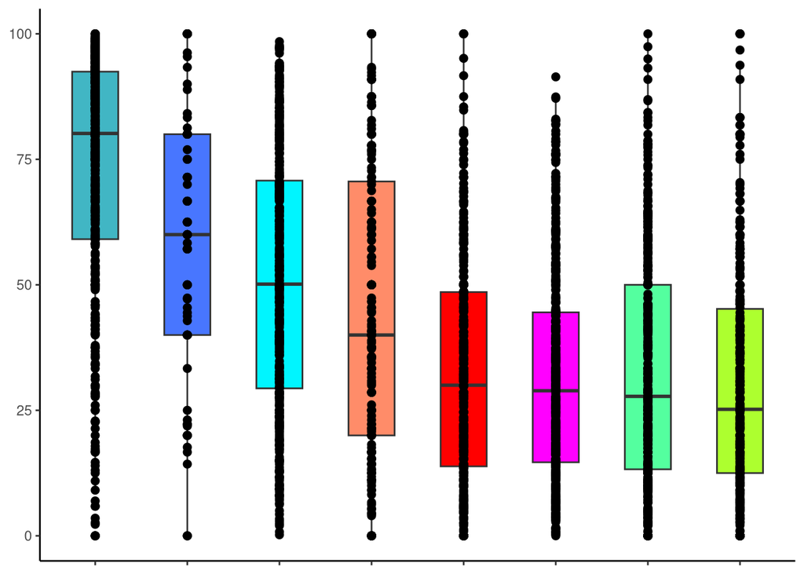

```r
> dodge <- 1
> run_name <- "Sorin_CD14subsets_h3"
>
> percentages_df$percentage <- factor(percentages_df$percentage,
+                                     levels = unique(percentages_df$percentage))
>
> cd14pos_colors_h3 <- c(
+     "red",
+     "magenta1",
+     "turquoise1",
+     "#41b6c4",
+     "seagreen1",
+     "greenyellow",
+     "royalblue1",
+     "salmon1"
+     )
>
> #Here we need to reorder by median value
> do_ordered_boxplot(percentages_df, cd14pos_colors_h3, dodge)
```

```r
> ggsave(file.path(output_folder, paste0(run_name, "_no_pvalue_boxplots.png")))
```

> For Fig 4, A, we need to add NK in our cohort and Sorin (and I will put LUSC in supp).

> For C (I) I will remove LUSC to put in supp (nned to remove NK and dd treg), for both (I) and (II) remove NK cells and add Treg